# Análisis de la estructura del conocimiento en la carrera de Estadística de la Universidad Nacional de Colombia sede Bogotá

María Paula Camargo Rincón

2026-07-26

# 1 Introducción

El diseño de un plan de estudios constituye un elemento fundamental en la formación académica, ya que establece la secuencia en la que los estudiantes adquieren y consolidan los conocimientos necesarios para su desarrollo profesional. Una adecuada definición de las relaciones de prerrequisito entre asignaturas favorece una progresión coherente del aprendizaje y contribuye a fortalecer la articulación entre los diferentes componentes curriculares.

En el contexto del programa académico objeto de este estudio, actualmente se encuentra en desarrollo un proceso de actualización curricular orientado a la construcción de un nuevo pensum. En este escenario, resulta de interés disponer de herramientas que permitan analizar objetivamente la estructura del conocimiento impartido en las asignaturas y generar evidencia que apoye la definición de relaciones de dependencia entre ellas.

Con este propósito, en este trabajo se modela el conjunto de conceptos abordados en las asignaturas como una red, donde los nodos representan conceptos y las aristas representan relaciones de dependencia conceptual. Sobre esta representación se aplican diferentes metodologías de análisis de redes, incluyendo el modelo de bloques estocásticos (Stochastic Block Model, SBM), el algoritmo de detección de comunidades de Louvain y los modelos de espacio latente. Estas técnicas permiten identificar grupos de conceptos estrechamente relacionados y estudiar la organización estructural del conocimiento dentro del currículo.

Finalmente, a partir de la estructura conceptual identificada y de la asociación entre conceptos y asignaturas, se analizan las posibles relaciones de prerrequisito entre cursos. De esta manera, el estudio proporciona una aproximación basada en datos para apoyar el proceso de diseño curricular, ofreciendo una perspectiva complementaria a la experiencia de los expertos académicos encargados de la construcción del nuevo plan de estudios.

# 2 Bases de datos

La base de datos utilizada en este trabajo fue construida a partir de información oficial de la Universidad Nacional de Colombia. Como punto de partida se empleó el Proyecto Educativo del Programa (PEP) de la carrera de Estadística, en el cual se identificaron las asignaturas del plan de estudios, el componente curricular al que pertenecen, el número de créditos y su carácter obligatorio o electivo (Universidad Nacional de Colombia s.f.c).

Con el propósito de recuperar la mayor cantidad posible de información histórica y completar la base de datos, también se consultó el repositorio de (Universidad Nacional de Colombia s.f.b) de la Universidad Nacional de Colombia (Universidad Nacional de Colombia s.f.b). Esta fuente permitió obtener programas académicos y descripciones de algunas asignaturas que ya no se ofertan, pero que forman parte del plan de estudios considerado en esta investigación.

A partir de la información recopilada se realizó un proceso de extracción y organización de los contenidos conceptuales de cada asignatura, construyéndose posteriormente las relaciones de dependencia entre conceptos y su asociación con los respectivos cursos. Como resultado se obtuvo una base de datos relacional compuesta por cuatro tablas principales.

## 2.1 Estructura de la base de datos

La base de datos está conformada por las siguientes cuatro tablas:

- **CONCEPTOS**: contiene el identificador único de cada concepto, el nombre del concepto y una breve descripción de su contenido.
- **CONCEPTOS_RELACIONES**: almacena las relaciones de dependencia entre conceptos. Cada registro está compuesto por un concepto de origen y un concepto de destino, donde la relación indica que el concepto de origen constituye un conocimiento previo necesario para comprender el concepto de destino.
- **CURSOS**: registra la información general de cada asignatura, incluyendo un identificador único, el nombre del curso, el componente curricular al que pertenece, el número de créditos y si corresponde a una asignatura obligatoria o electiva.

Las cuatro tablas constituyen una representación relacional del conocimiento del programa de Estadística y sirven como insumo para la construcción de las redes de conceptos y de cursos analizadas en los capítulos posteriores.

**Los componentes curriculares considerados son**:

```r
library(readxl)
library(igraph)
library(dplyr)
library(viridisLite)
library(blockmodels)
library(tidyr)
library(network)
library(latentnet)
library(intergraph)
library(ggplot2)
library(ggrepel)
library(stringr)
library(kableExtra)
```

```r
# Creación red de conceptos
conceptos <- read_excel(
  "BASES.xlsx",
  sheet = "CONCEPTOS"
)

conceptos$ID_concepto <- as.character(conceptos$ID_concepto)

relaciones <- read_excel(
  "BASES.xlsx",
  sheet = "CONCEPTOS_RELACIONES"
)

g_conceptos <- graph_from_data_frame(
  d = relaciones,
  vertices = conceptos,
  directed = TRUE
)

V(g_conceptos)$size <- scales::rescale(
  degree(g_conceptos, mode = "out"),
  to = c(4, 12)
)

roots <- V(g_conceptos)[degree(g_conceptos, mode = "in") == 0]

D <- distances(
  g_conceptos,
  v = roots,
  to = V(g_conceptos),
  mode = "out"
)

nivel <- apply(D, 2, min)
nivel[is.infinite(nivel)] <- NA

V(g_conceptos)$nivel <- nivel

pal <- viridis(
  max(nivel, na.rm = TRUE) + 1,
  option = "C"
)

V(g_conceptos)$color <- pal[nivel + 1]

set.seed(1302)
lay <- layout_with_sugiyama(
  g_conceptos
)$layout

g_louvain <- as_undirected(
  g_conceptos,
  mode = "collapse"
)

com <- cluster_louvain(g_louvain)

membership <- membership(com)

V(g_conceptos)$comunidad <- membership

k <- length(unique(membership))

cols <- viridis(
  k,
  option = "turbo"
)

V(g_conceptos)$color2 <- cols[membership]


# Creación red bipartita CURSOS-CONCEPTOS
cursos <- read_excel(
  "BASES.xlsx",
  sheet = "CURSOS"
)

cursos <- cursos %>%
  filter(!is.na(ID_curso)) # eliminando NA's que son los cursos que no se ofertan

curso_concepto <- read_excel(
  "BASES.xlsx",
  sheet = "CURSOS-CONCEPTOS"
)

vertices <- rbind(
  data.frame(
    name = cursos$ID_curso,
    tipo = "Curso"
  ),
  data.frame(
    name = conceptos$ID_concepto,
    tipo = "Concepto"
  )
)

vertices <- vertices  %>%
  left_join(
    cursos  %>%
      select(ID_curso, Obligatoria),
    by = c("name" = "ID_curso")
  )

g_bip <- graph_from_data_frame(
  d = curso_concepto[, c("ID_curso", "ID_concepto")],
  vertices = vertices,
  directed = FALSE
)

vertices$grado <- degree(g_bip) #grado de la red bipartita para visualización

vertices$color <- case_when(
  vertices$tipo == "Concepto" ~ "grey80",
  vertices$Obligatoria == "sí" ~ "#2C7BB6", # Si es obligatoria entonces azul
  TRUE ~ "#D7191C" # de lo contrario rojo
)

vertices$size <- ifelse( # tamaño de los vértices de acuerdo al grado
  vertices$tipo == "Concepto",
  scales::rescale(vertices$grado,
                  to = c(4, 12)),
  8
)

vertices$shape <- ifelse(
  vertices$tipo == "Curso",
  "square",
  "circle"
)

V(g_bip)$color <- vertices$color
V(g_bip)$size <- vertices$size
V(g_bip)$shape <- vertices$shape
```

# 3 tabla resumen

```r
resumen_red <- function(g, bipartito = FALSE) {

  data.frame(
    Tipo = ifelse(is_directed(g), "Dirigido", "No dirigido"),
    Bipartito = ifelse(bipartito, "Sí", "No"),
    Orden = gorder(g),
    'Tamaño' = gsize(g),
    Conectado = ifelse(
      is_connected(g, mode = "weak"),
      "Sí",
      "No"
    ),
    Componentes = components(g, mode = "weak")$no,
    Densidad = round(edge_density(g), 4),
    Grado_medio = round(mean(degree(g)), 2)
  )
}

tabla <- rbind(
  "Conceptos" = resumen_red(g_conceptos),
  "Cursos-Conceptos" = resumen_red(g_bip, bipartito = TRUE)
)
```

```r
tabla %>%
  kableExtra::kbl(
    caption = "Tabla resumen de los 2 grafos",
    digits = 3
  ) %>%
  kableExtra::kable_minimal()
```

Table 3.1: Tabla resumen de los 2 grafos

|  | Tipo | Bipartito | Orden | Tamaño | Conectado | Componentes | Densidad | Grado_medio |
| --- | --- | --- | --- | --- | --- | --- | --- | --- |
| Conceptos | Dirigido | No | 265 | 326 | No | 6 | 0.005 | 2.46 |
| Cursos-Conceptos | No dirigido | Sí | 321 | 345 | No | 38 | 0.007 | 2.15 |

- **Densidad:** La densidad es muy baja en ambas redes (0.005 y 0.007), lo cual es entendible, debido a que en la red de conceptos no todos los conceptos dependen de todos los demás, únicamente existen relaciones de prerrequisito cuando son necesarias. Y por otro lado en la red bipartita un curso solamente aborda una pequeña fracción del total de conceptos disponibles. En conclusión ambas redes son dispersas.
- **Grado promedio:** El grado promedio es bastante similar y este indica que, en promedio, cada nodo mantiene únicamente dos o tres relaciones con otros nodos, reforzando la idea de una estructura poco densa.
- **Conectividad:** Ninguna de las dos redes es conectada, sin embargo el número de componentes de ambas es muy diferente, mientras que la red de conceptos posee únicamente 6 componentes, la red cursos–conceptos posee 38 componentes, mostrando una fragmentación mucho mayor, entonces en la red de conceptos se puede pensar que la mayor parte del conocimiento se organiza en unos pocos bloques relativamente grandes.

# 4 Red de conceptos

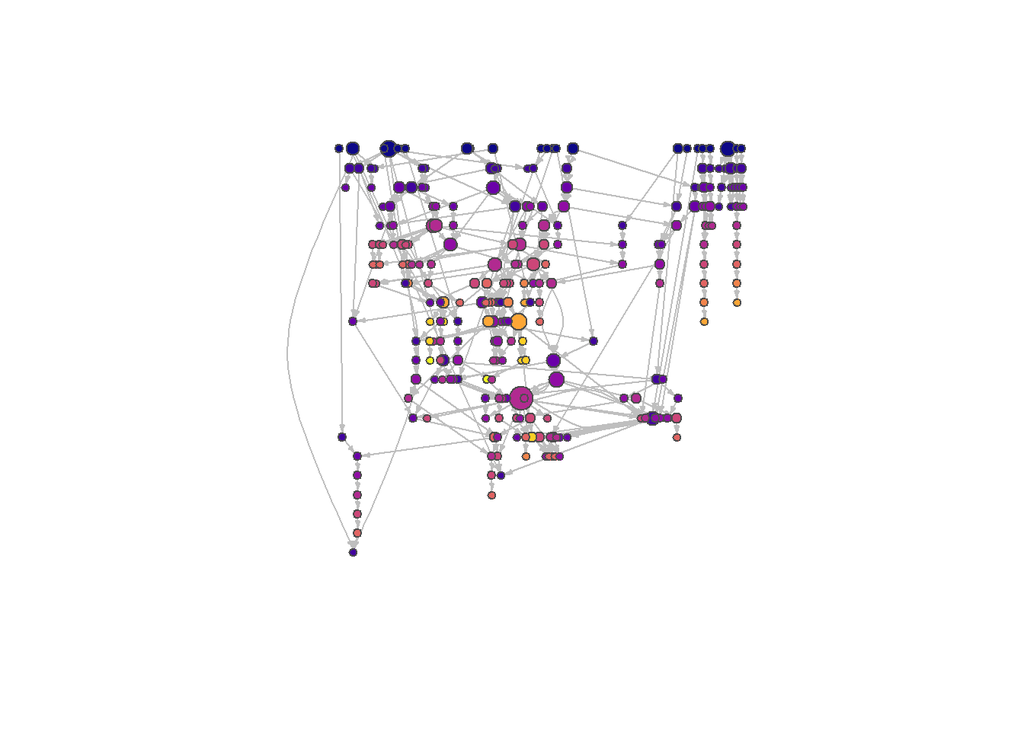

Figure 4.1: Visualización de la red de conceptos

```r
plot(
  g_conceptos,
  layout = lay,
  vertex.color = V(g_conceptos)$color,
  vertex.size = V(g_conceptos)$size,
  vertex.frame.color = "grey30",
  edge.arrow.size = .25,
  edge.color = "grey75",
  vertex.label = ""
)
```

- **Color de los nodos**: representa el **nivel conceptual** del concepto dentro de la red de prerrequisitos, calculado como la **distancia mínima** desde los conceptos sin prerrequisitos. Los colores oscuros corresponden a conceptos fundacionales, mientras que los colores claros representan conceptos más avanzados.
- **Tamaño de los nodos**: proporcional al **grado de salida**, es decir, al número de conceptos que dependen directamente de cada concepto.

En general, este grafo ya transmite una idea importante: el conocimiento no aparece como una lista de conceptos aislados, sino como una red jerárquica de dependencias donde existen conceptos fundamentales que sirven de base para múltiples rutas de aprendizaje y otros conceptos especializados que solo pueden abordarse después de recorrer varios prerrequisitos. Esa es precisamente la interpretación que se espera de una red concepto–concepto.

# 5 Red bipartita entre cursos y conceptos

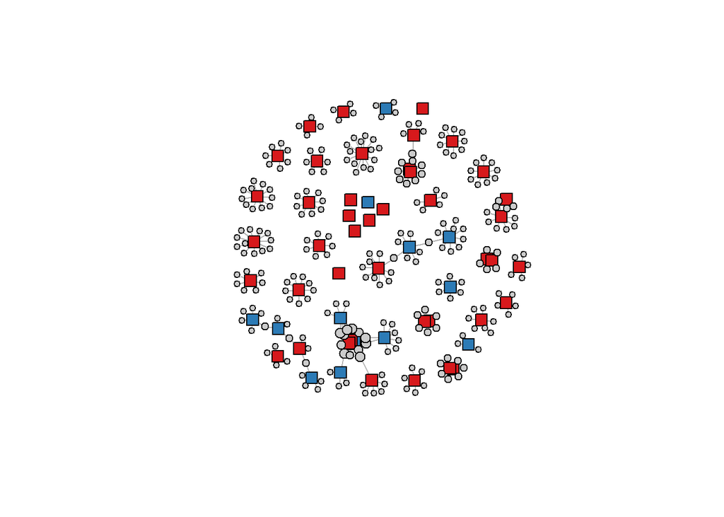

Figure 5.1: Visualización de la red bipartita entre cursos y conceptos

```r
set.seed(1238)
plot(
  g_bip,
  vertex.label.cex = 0.6,
  vertex.label="",
  edge.color = "grey70",
  layout = layout_with_fr(g_bip)
)
```

En esta red los nodos cuadrados representan los cursos y los nodos circulares representan los conceptos.

Una arista indica que un determinado concepto se aborda dentro de un curso.

Para facilitar la interpretación:

- Cuadrados azules: **cursos obligatorios**.
- Cuadrados rojos: **cursos optativos**.
- Círculos grises: **conceptos**.
- El tamaño de los conceptos es proporcional al número de cursos en los que aparecen.

La red bipartita evidencia que la mayoría de los cursos presentan conjuntos de conceptos propios, formando estructuras tipo estrella donde un curso se relaciona principalmente con contenidos exclusivos. Sin embargo, también se identifican conceptos compartidos entre diferentes asignaturas, los cuales generan conexiones entre cursos obligatorios y optativos. Estos conceptos pueden interpretarse como ejes transversales del currículo, al aparecer en múltiples espacios académicos y facilitar la integración del conocimiento. Por otra parte, el aislamiento del curso de Seminario responde a la ausencia de un programa analítico con conceptos definidos y no a una falta de relación con el resto del plan de estudios.

# 6 Modelos de comunidades

## 6.1 SBM

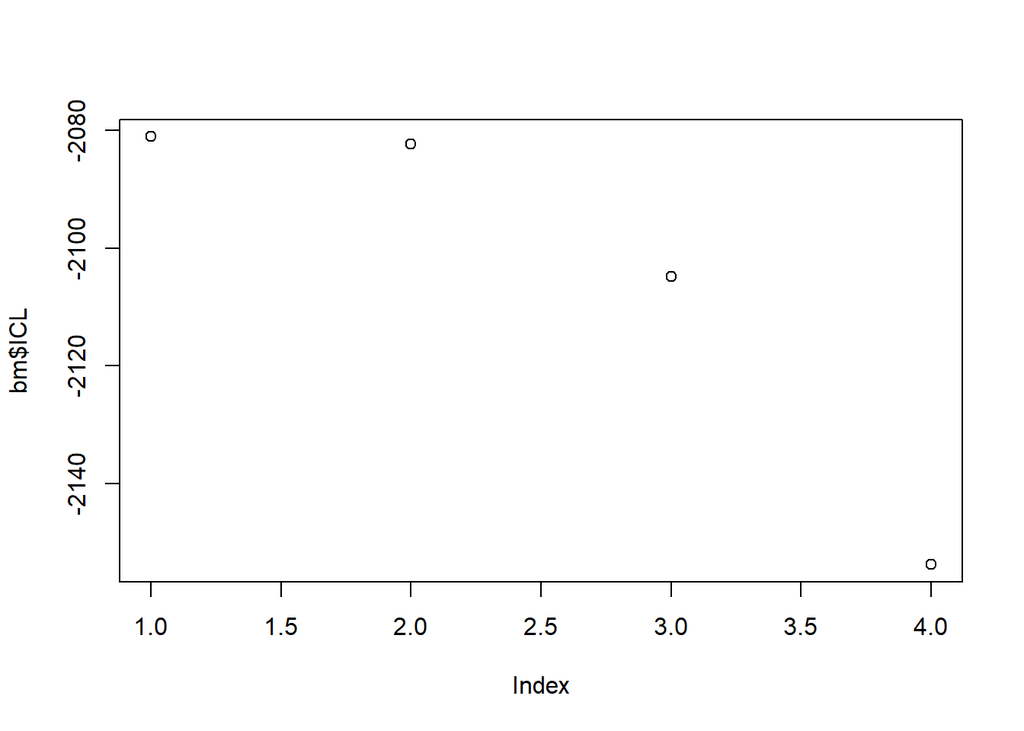

Figure 6.1: Criterio ICL para las distintas cantidades de bloques

```r
plot(bm$ICL)
```

El criterio ICL alcanzó su máximo para un único bloque, lo que indica que, bajo los supuestos del Stochastic Block Model, la red presenta una estructura global relativamente homogénea y no se identifican comunidades estadísticamente bien diferenciadas. Esto sugiere que los conceptos se encuentran altamente interconectados y que las fronteras entre áreas de conocimiento no son suficientemente marcadas para ser detectadas por un modelo probabilístico de bloques.

## 6.2 Louvain

El algoritmo de Louvain identificó 18 comunidades con una modularidad de 0.811, lo que indica una estructura comunitaria altamente marcada. Esto sugiere que los conceptos no se encuentran distribuidos de forma homogénea en la red, sino organizados en núcleos conceptuales con una elevada conectividad interna y relativamente pocas relaciones con conceptos pertenecientes a otras comunidades.

```r
g_louvain <- as_undirected(
  g_conceptos,
  mode = "collapse"
)

com <- cluster_louvain(g_louvain)

membership <- membership(com)

tabla_comunidades <- table(membership) |>
  as.data.frame() |>
  rename(
    comunidad = membership,
    numero_conceptos = Freq
  ) |>
  mutate(
    comunidad = as.integer(as.character(comunidad))
  ) |>
  arrange(desc(numero_conceptos))

V(g_conceptos)$comunidad <- membership

k <- length(unique(membership))

cols <- viridis(
  k,
  option = "turbo"
)

V(g_conceptos)$color2 <- cols[membership]

#modularity(com)

tabla_comunidad <- tibble(
  concepto = V(g_conceptos)$concepto,
  comunidad = membership(com)
)
```

### 6.2.1 Comunidades

Aunque las comunidades identificadas por Louvain no corresponden necesariamente a asignaturas individuales, sí representan núcleos conceptuales coherentes del currículo. En varios casos, una comunidad agrupa conceptos provenientes de diferentes cursos que comparten una misma función dentro del proceso de formación. Esto evidencia que la organización conceptual del plan de estudios trasciende la división administrativa de las asignaturas y refleja dependencias de conocimiento entre distintas áreas.

```r
tabla_comunidades |>
  kbl(
    caption = "Tamaño de las comunidades detectadas mediante el algoritmo de Louvain.",
    align = c("c", "c"),
    digits = 0
  ) |>
  kable_minimal() |>
  row_spec(0, bold = TRUE)
```

Table 6.1: Tamaño de las comunidades detectadas mediante el algoritmo de Louvain.

| comunidad | numero_conceptos |
| --- | --- |
| 2 | 40 |
| 3 | 27 |
| 14 | 22 |
| 5 | 21 |
| 12 | 18 |
| 1 | 17 |
| 8 | 13 |
| 9 | 13 |
| 4 | 12 |
| 7 | 12 |
| 13 | 12 |
| 6 | 11 |
| 16 | 10 |
| 17 | 9 |
| 10 | 8 |
| 11 | 8 |
| 15 | 6 |
| 18 | 6 |

### 6.2.2 Red total

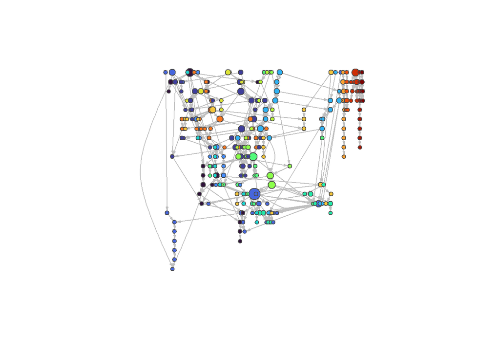

```r
plot(
  g_conceptos,
  layout = lay,
  vertex.color = V(g_conceptos)$color2,
  vertex.size = V(g_conceptos)$size,
  vertex.frame.color = "grey30",
  edge.color = "grey75",
  edge.arrow.size = 0.25,
  vertex.label = ""
)
```

### 6.2.3 Comunidad 2 (40 conceptos)

#### 6.2.3.1 Gráfico

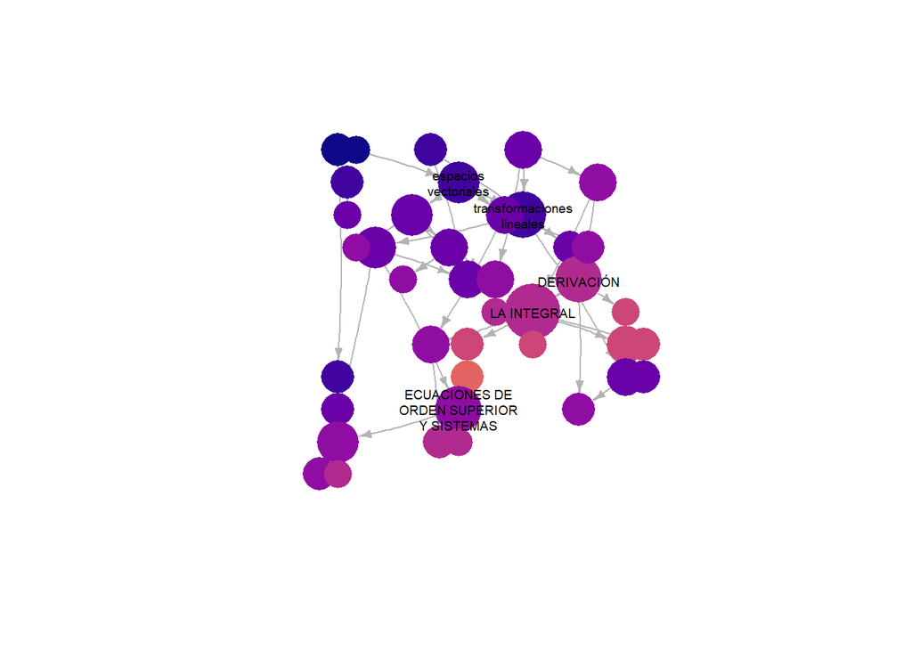

```r
g1 <- induced_subgraph(
    g_conceptos,
    membership(com) == 2
)

layoutgcursos <- layout_with_sugiyama(g1)$layout
V(g1)$size <- scales::rescale(
  degree(g1, mode = "all"),
  to = c(18, 35)
)
grado <- degree(g1, mode = "all")

V(g1)$label <- ""

idx <- order(grado, decreasing = TRUE)[1:5]

V(g1)$label[idx] <- str_wrap(
  V(g1)$concepto[idx],
  width = 14
)
plot(
  g1,
  layout=layoutgcursos,
  edge.color = "grey70",
  vertex.frame.color = NA,
  edge.arrow.size = .45,
edge.width = scales::rescale(E(g1)$peso, c(1.5,6)),
edge.color = "grey55",
edge.curved = .05,
vertex.label.cex = .6,
vertex.label.family = "sans",
vertex.label.color = "black"
)
```

#### 6.2.3.2 Tabla

```r
tabla_comunidad %>%
  dplyr::filter(comunidad==2) %>%
  head(20) %>%
  dplyr::select(concepto) %>%
  kableExtra::kbl(
    caption = "20 conceptos en la comunidad",
    align = c("c", "c"),
    digits = 0
  ) |>
  kableExtra::kable_minimal() |>
  row_spec(0, bold = TRUE)
```

Table 6.2: 20 conceptos en la comunidad

| concepto |
| --- |
| vectores en R^n |
| espacios vectoriales |
| transformaciones lineales |
| valores y vectores propios |
| producto interno |
| Matrices especiales |
| Formas lineales, bilineales y cuadráticas |
| Descomposición de matrices |
| Diferenciación de matrices y aplicaciones |
| LÍMITES Y CONTINUIDAD |
| DERIVACIÓN |
| APLICACIONES DE LAS DERIVADAS. |
| LA INTEGRAL |
| MÉTODOS DE INTEGRACIÓN |
| APLICACIONES DE LA INTEGRAL |
| COORDENADAS POLARES |
| SUCESIONES Y SERIES |
| CÁLCULO EN VARIAS VARIABLES |
| INTEGRALES DOBLES Y TRIPLES |
| CÁLCULO VECTORIAL |

### 6.2.4 Comunidad 3 (27 conceptos)

#### 6.2.4.1 Gráfico

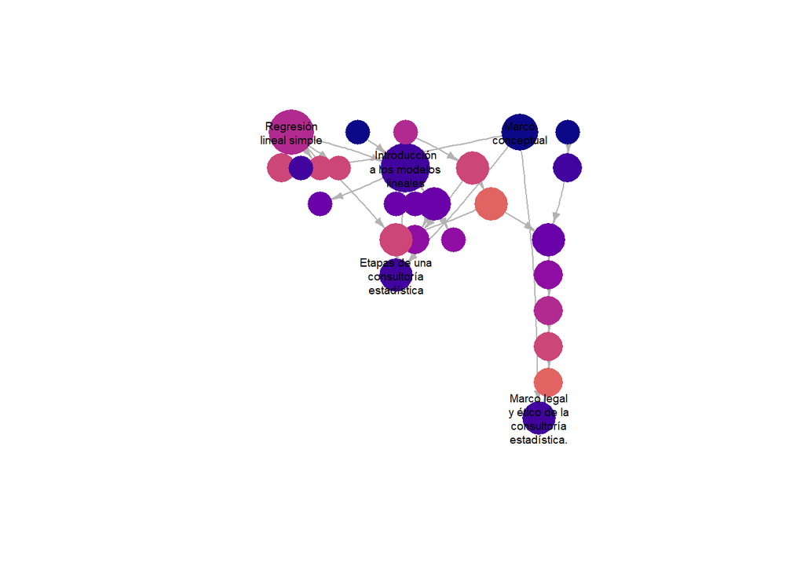

```r
g1 <- induced_subgraph(
    g_conceptos,
    membership(com) == 3
)

layoutgcursos <- layout_with_sugiyama(g1)$layout
V(g1)$size <- scales::rescale(
  degree(g1, mode = "all"),
  to = c(18, 35)
)
grado <- degree(g1, mode = "all")

V(g1)$label <- ""

idx <- order(grado, decreasing = TRUE)[1:5]

V(g1)$label[idx] <- str_wrap(
  V(g1)$concepto[idx],
  width = 14
)
plot(
  g1,
  layout=layoutgcursos,
  edge.color = "grey70",
  vertex.frame.color = NA,
  edge.arrow.size = .45,
edge.width = scales::rescale(E(g1)$peso, c(1.5,6)),
edge.color = "grey55",
edge.curved = .05,
vertex.label.cex = .6,
vertex.label.family = "sans",
vertex.label.color = "black"
)
```

#### 6.2.4.2 Tabla

```r
tabla_comunidad %>%
  dplyr::filter(comunidad==3) %>%
  head(20) %>%
  dplyr::select(concepto) %>%
  kableExtra::kbl(
    caption = "20 conceptos en la comunidad",
    align = c("c", "c"),
    digits = 0
  ) |>
  kableExtra::kable_minimal() |>
  row_spec(0, bold = TRUE)
```

Table 6.3: 20 conceptos en la comunidad

| concepto |
| --- |
| Regresión lineal simple |
| Regresión logística |
| Diagnostico del modelo |
| Principios del análisis de concordancia |
| Marco conceptual |
| La consultoría estadística en contexto |
| Etapas de una consultoría estadística |
| Marco legal y ético de la consultoría estadística. |
| Principios del diseño de experimentos |
| Introducción a los modelos lineales |
| Diseños Completamente Aleatorizados |
| Diseños en bloques completos aleatorizados |
| Diseños en cuadrados latinos y grecolatinos |
| Diseños factoriales |
| Introducción a la metodología de superficies de respuesta. |
| El valor de la información estadística en la sociedad y estados modernos |
| Aspectos filosóficos sobre medición y clasificación |
| Normalización de las estadísticas oficiales y armonización internacional |
| Los sistemas estadísticos nacionales |
| Vigilancia del estado sobre producción estadística |

### 6.2.5 Comunidad 14 (22 conceptos)

Esta comunidad agrupa conceptos de materias de **programación**, por lo que este componente es claramente de programación.

#### 6.2.5.1 Gráfico

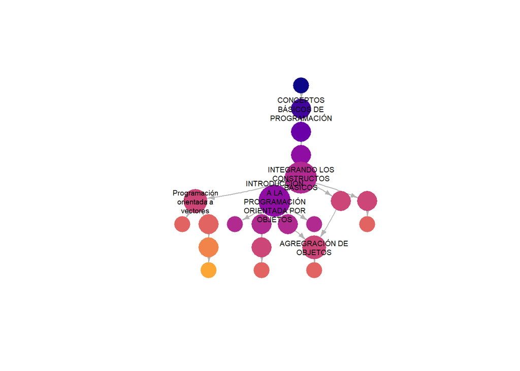

```r
g1 <- induced_subgraph(
    g_conceptos,
    membership(com) == 14
)

layoutgcursos <- layout_with_sugiyama(g1)$layout
V(g1)$size <- scales::rescale(
  degree(g1, mode = "all"),
  to = c(18, 35)
)
grado <- degree(g1, mode = "all")

V(g1)$label <- ""

idx <- order(grado, decreasing = TRUE)[1:5]

V(g1)$label[idx] <- str_wrap(
  V(g1)$concepto[idx],
  width = 14
)
plot(
  g1,
  layout=layoutgcursos,
  edge.color = "grey70",
  vertex.frame.color = NA,
  edge.arrow.size = .45,
edge.width = scales::rescale(E(g1)$peso, c(1.5,6)),
edge.color = "grey55",
edge.curved = .05,
vertex.label.cex = .6,
vertex.label.family = "sans",
vertex.label.color = "black"
)
```

#### 6.2.5.2 Tabla

```r
tabla_comunidad %>%
  dplyr::filter(comunidad==14) %>%
  dplyr::select(concepto) %>%
  kableExtra::kbl(
    caption = "Conceptos en la comunidad",
    align = c("c", "c"),
    digits = 0
  ) |>
  kableExtra::kable_minimal() |>
  row_spec(0, bold = TRUE)
```

Table 6.4: Conceptos en la comunidad

| concepto |
| --- |
| INTRODUCCIÓN A LA PROGRAMACIÓN DE COMPUTADORES |
| CONCEPTOS BÁSICOS DE PROGRAMACIÓN |
| CONSTRUCTOS BÁSICOS I (ASIGNACIÓN Y SECUENCIA) DE PROGRAMACIÓN |
| CONSTRUCTOS BÁSICOS II y III (CONDICIONALES) DE PROGRAMACIÓN |
| INTEGRANDO LOS CONSTRUCTOS BÁSICOS |
| ARREGLOS |
| Funciones (C++,R) |
| Clases y objetos (C++,R) |
| Programación orientada a vectores |
| Objeto factor en R |
| Arreglos y matrices en R |
| Manipulación de objetos en R |
| Elementos de programación en SAS |
| INTRODUCCIÓN A LA PROGRAMACIÓN ORIENTADA POR OBJETOS |
| HERENCIA Y POLIFORMISMO |
| INTEGRANDO LA PROGRAMACIÓN ESTRUCTURADA Y LA PROGRAMACIÓN ORIENTADA POR OBJETOS |
| AGREGRACIÓN DE OBJETOS |
| PATRONES Y COLECCIONES |
| FLUJOS DE DATOS Y EXCEPCIONES |
| INTERFAZ GRÁFICA DE USUARIO. Interfaz gráfica de usuario (GUI) |
| Conversiones y Casting en Java |
| Los paquetes Java.lang y Java.util |

### 6.2.6 Comunidad 5 (21 conceptos)

Esta comunidad agrupa concepto de 4 materias: **bioestadística, indicadores sociales, epidemiología** y **probabilidad**, esto se puede deber a que comparten conceptos de probabilidad para su respectiva aplicación, por lo que este componente se puede considerar como uno de **fundamentos probabilísticos y aplicaciones en estadística oficial y salud**.

#### 6.2.6.1 gráfico

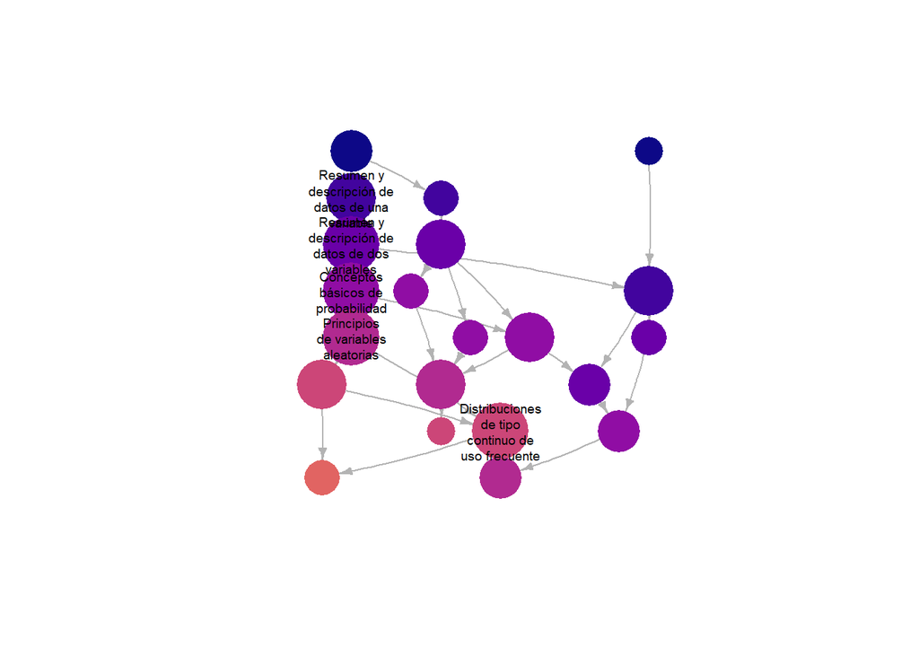

```r
g1 <- induced_subgraph(
    g_conceptos,
    membership(com) == 5
)

layoutgcursos <- layout_with_sugiyama(g1)$layout
V(g1)$size <- scales::rescale(
  degree(g1, mode = "all"),
  to = c(18, 35)
)
grado <- degree(g1, mode = "all")

V(g1)$label <- ""

idx <- order(grado, decreasing = TRUE)[1:5]

V(g1)$label[idx] <- str_wrap(
  V(g1)$concepto[idx],
  width = 14
)
plot(
  g1,
  layout=layoutgcursos,
  edge.color = "grey70",
  vertex.frame.color = NA,
  edge.arrow.size = .45,
edge.width = scales::rescale(E(g1)$peso, c(1.5,6)),
edge.color = "grey55",
edge.curved = .05,
vertex.label.cex = .6,
vertex.label.family = "sans",
vertex.label.color = "black"
)
```

#### 6.2.6.2 Tabla

```r
tabla_comunidad %>%
  dplyr::filter(comunidad==5) %>%
  dplyr::select(concepto) %>%
  kableExtra::kbl(
    caption = "Conceptos en la comunidad",
    align = c("c", "c"),
    digits = 0
  ) |>
  kableExtra::kable_minimal() |>
  row_spec(0, bold = TRUE)
```

Table 6.5: Conceptos en la comunidad

| concepto |
| --- |
| introducción estadística |
| Resumen y descripción de datos de una variable |
| Resumen y descripción de datos de dos variables |
| Conceptos básicos de probabilidad |
| Principios de variables aleatorias |
| Conceptos generales de introducción a la Epidemiología |
| Fundamentos de investigación epidemiológica |
| Medidas de frecuencia |
| Medidas de asociación y estudios descriptivos |
| Estudios epidemiológicos |
| Sesgo y efecto de confusión en Epidemiología |
| Introducción al uso de modelos estadísticos en la investigación epidemiológica |
| indicadores sociales |
| construcción de indicadores |
| indicadores sectoriales |
| pobreza |
| evaluación de políticas públicas |
| índices compuestos |
| Distribuciones discretas de uso frecuente |
| Distribuciones de tipo continuo de uso frecuente |
| Distribución conjunta de variables aleatorias |

### 6.2.7 Comunidad 12 (18 conceptos)

Esta comunidad agrupa concepto principalmente de 2 materias: **métodos no paramétricos** e **inteligencia artificial**.

#### 6.2.7.1 Gráfico

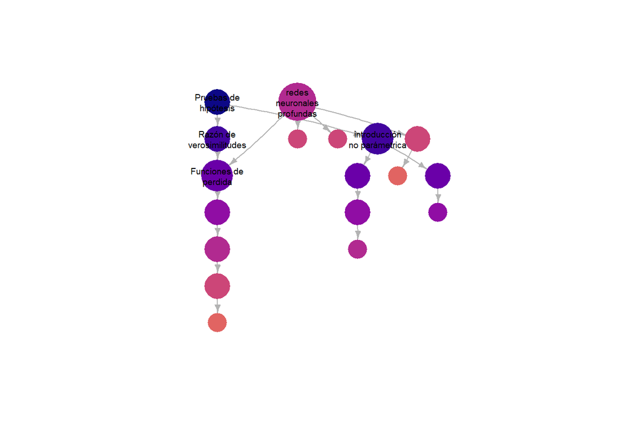

```r
g1 <- induced_subgraph(
    g_conceptos,
    membership(com) == 12
)

layoutgcursos <- layout_with_sugiyama(g1)$layout
V(g1)$size <- scales::rescale(
  degree(g1, mode = "all"),
  to = c(18, 35)
)
grado <- degree(g1, mode = "all")

V(g1)$label <- ""

idx <- order(grado, decreasing = TRUE)[1:5]

V(g1)$label[idx] <- str_wrap(
  V(g1)$concepto[idx],
  width = 14
)
plot(
  g1,
  layout=layoutgcursos,
  edge.color = "grey70",
  vertex.frame.color = NA,
  edge.arrow.size = .45,
edge.width = scales::rescale(E(g1)$peso, c(1.5,6)),
edge.color = "grey55",
edge.curved = .05,
vertex.label.cex = .6,
vertex.label.family = "sans",
vertex.label.color = "black"
)
```

#### 6.2.7.2 Tabla

```r
tabla_comunidad %>%
  dplyr::filter(comunidad==12) %>%
  dplyr::select(concepto) %>%
  kableExtra::kbl(
    caption = "Conceptos en la comunidad",
    align = c("c", "c"),
    digits = 0
  ) |>
  kableExtra::kable_minimal() |>
  row_spec(0, bold = TRUE)
```

Table 6.6: Conceptos en la comunidad

| concepto |
| --- |
| Pruebas de hipótesis |
| Razón de verosimilitudes |
| introducción no parámetrica |
| Métodos no paramétricos para una muestra |
| Métodos no paramétricos para dos muestras |
| Métodos no paramétricos para estimadores de localización en más de dos muestras |
| Estimación no paramétrica de la densidad |
| Regresión no paramétrica |
| redes neuronales profundas |
| Funciones de perdida |
| Ajustar modelos |
| gradientes e inicialización |
| medición del rendimiento |
| regularización |
| redes convolucionales |
| redes residuales |
| transformadores |
| redes generativas antagónicas |

### 6.2.8 Comunidad 1 (17 conceptos)

Esta comunidad agrupa concepto principalmente de 2 materias: **algebra matricial** e **series de tiempo univariadas**, esto se puede deber al uso que se le da a la algebra matricial con los modelos (en general).

#### 6.2.8.1 Gráfico

[figure not shown]

```r
g1 <- induced_subgraph(
    g_conceptos,
    membership(com) == 2
)

layoutgcursos <- layout_with_sugiyama(g1)$layout
V(g1)$size <- scales::rescale(
  degree(g1, mode = "all"),
  to = c(18, 35)
)
grado <- degree(g1, mode = "all")

V(g1)$label <- ""

idx <- order(grado, decreasing = TRUE)[1:5]

V(g1)$label[idx] <- str_wrap(
  V(g1)$concepto[idx],
  width = 14
)
plot(
  g1,
  layout=layoutgcursos,
  edge.color = "grey70",
  vertex.frame.color = NA,
  edge.arrow.size = .45,
edge.width = scales::rescale(E(g1)$peso, c(1.5,6)),
edge.color = "grey55",
edge.curved = .05,
vertex.label.cex = .6,
vertex.label.family = "sans",
vertex.label.color = "black"
)
```

#### 6.2.8.2 Tabla

```r
tabla_comunidad %>%
  dplyr::filter(comunidad==1) %>%
  dplyr::select(concepto) %>%
  kableExtra::kbl(
    caption = "Conceptos en la comunidad",
    align = c("c", "c"),
    digits = 0
  ) |>
  kableExtra::kable_minimal() |>
  row_spec(0, bold = TRUE)
```

Table 6.7: Conceptos en la comunidad

| concepto |
| --- |
| matrices |
| sistemas de ecuaciones lineales |
| determinantes |
| submatrices y matrices particionadas |
| producto Kronecker de dos o más matrices |
| operador Vec y Vech |
| Inversas generalizadas y de Moore Penrose |
| Tópicos adicionales sobre determinantes |
| Regresión lineal múltiple |
| Procesos ARMA estacionarios. |
| Representación espectral de un proceso estacionario. |
| Teoría de predicción de procesos estocásticos estacionarios |
| Inferencia sobre las funciones de medias y de autocorrelación de un proceso estacionario. |
| Estimación y validación de modelos ARMA. |
| Procesos no estacionarios y estacionales SARIMA. |
| Modelos de intervención. |
| Análisis de series de tiempo por medio de modelos de componentes no observables. |

# 7 Espacio latente

Para las visualizaciones por componentes se utlizan las que anteriormente se habían encontrado con el algoritmo de *Louvain*.

Mientras el algoritmo de Louvain identifica comunidades, con el modelo espacio latente podemos analizar mejor como se comportan estas comunidades dentro de sí, un resultado general es que no son homogeneas y en la mayoría se encuentran subgrupos de conceptos que normalmente le pertenecen a una materia.

```r
relaciones2 <- relaciones  %>%
  distinct(
    ID_concepto_origen,
    ID_concepto_destino,
    .keep_all = TRUE
  )
net <- graph_from_data_frame(
  relaciones2,
  directed = TRUE
)
net <- asNetwork(net)

set.seed(2103)

#lsm <- ergmm(
#  net ~ euclidean(d = 2),
#)

#saveRDS(
#  lsm,
#  file = "modelo_espacio_latente.rds"
#)

lsm <- readRDS("modelo_espacio_latente.rds")

coord <- as.data.frame(lsm$mkl$Z)

coord$ID_concepto <- V(g_conceptos)$name
coord$grado <- degree(g_conceptos)

coord$comunidad <- factor(
  membership(com)[coord$ID_concepto]
)

coord <- coord |>
  left_join(
    conceptos |>
      select(ID_concepto, concepto),
    by = c("ID_concepto" = "ID_concepto")
  )

coord$bt <- betweenness(g_conceptos)
```

## 7.1 Red completa

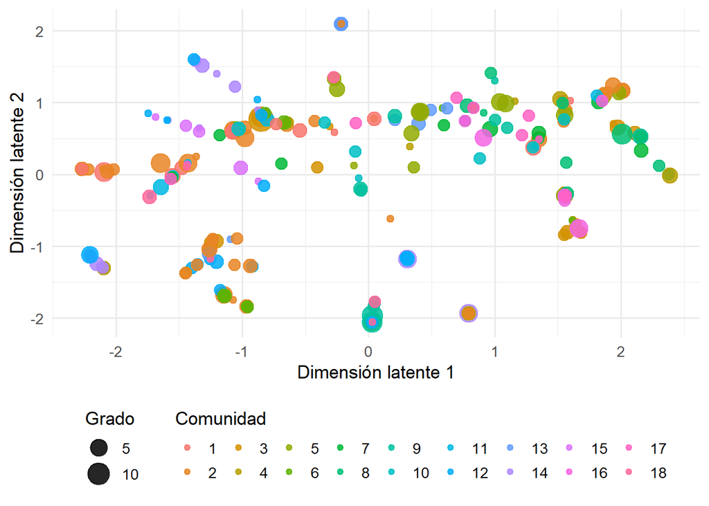

```r
ggplot(
  coord,
  aes(
    x = V1,
    y = V2,
    color = comunidad,
    size = grado
  )
) +
  geom_point(alpha = .85) +
  scale_size(range = c(2,8)) +
  labs(
    x = "Dimensión latente 1",
    y = "Dimensión latente 2",
    color = "Comunidad",
    size = "Grado"
  ) +
  guides(
  colour = guide_legend(nrow = 2, direction = "vertical"),
  size=guide_legend(nrow = 2, direction = "vertical")
) +
  theme_minimal(base_size = 13) +

    theme(
      legend.position = "bottom"
    )
```

## 7.2 Comunidad 2 (40 conceptos)

Se observa que la comunidad no es homogénea y que hay varios subconjuntos de conceptos, por ejemplo podemos distinguir un subconjunto de cálculos, como lo es con **la integral, funciones** y **derivación**

```r
coord_c2 <- coord |>
  dplyr::filter(comunidad == 2)


etiquetas <- coord_c2 |>
  slice_max(grado, n = 10)
```

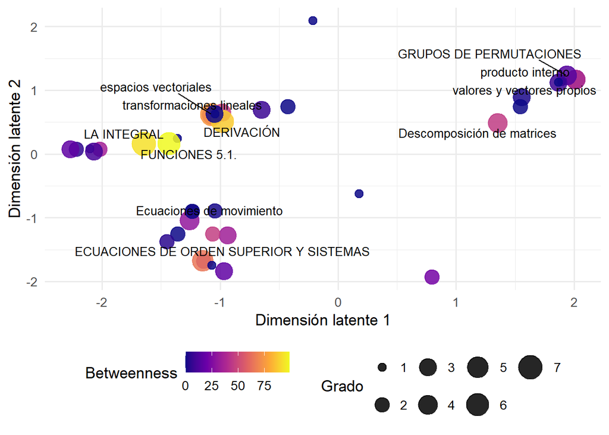

```r
ggplot(
  coord_c2,
  aes(
    V1,
    V2
  )
) +
  geom_point(
    aes(
      size = grado,
      color = bt
    ),
    alpha = .85
  ) +
  geom_text_repel(
    data = etiquetas,
    aes(label = concepto),
    size = 3.5,
    max.overlaps = Inf
  ) +
  scale_color_viridis_c(
    option = "C"
  ) +
  scale_size(range = c(3, 9)) +
  labs(
    x = "Dimensión latente 1",
    y = "Dimensión latente 2",
    color = "Betweenness",
    size = "Grado"
  ) +
  theme_minimal(base_size = 13) +
  theme(
    legend.position = "bottom"
  )
```

## 7.3 Comunidad 3 (27 conceptos)

Se observa que la comunidad no es homogénea y que hay varios subconjuntos de conceptos, por ejemplo se podría decir que hay algunos distintivos de muestreo agrupados, igualmente de regresión y consultoría.

```r
coord_c2 <- coord |>
  dplyr::filter(comunidad == 3)


etiquetas <- coord_c2 |>
  slice_max(grado, n = 10)
```

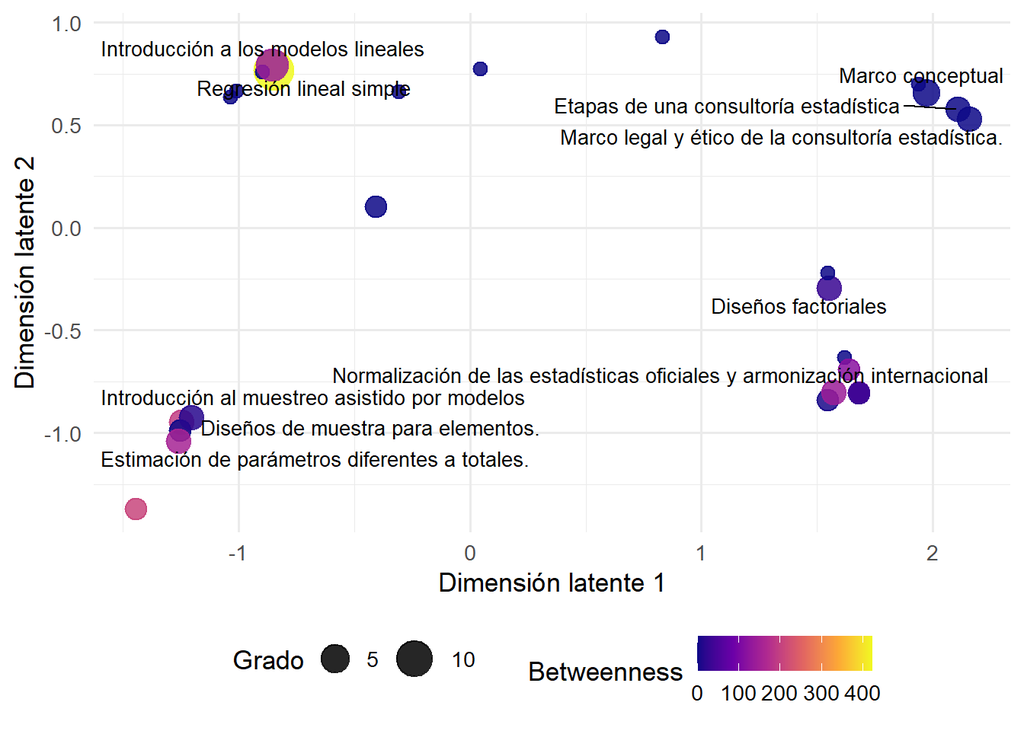

```r
ggplot(
  coord_c2,
  aes(
    V1,
    V2
  )
) +
  geom_point(
    aes(
      size = grado,
      color = bt
    ),
    alpha = .85
  ) +
  geom_text_repel(
    data = etiquetas,
    aes(label = concepto),
    size = 3.5,
    max.overlaps = Inf
  ) +
  scale_color_viridis_c(
    option = "C"
  ) +
  scale_size(range = c(3, 9)) +
  labs(
    x = "Dimensión latente 1",
    y = "Dimensión latente 2",
    color = "Betweenness",
    size = "Grado"
  ) +
  theme_minimal(base_size = 13) +
  theme(
    legend.position = "bottom"
  )
```

## 7.4 Comunidad 14 (22 conceptos)

```r
coord_c2 <- coord |>
  dplyr::filter(comunidad == 14)


etiquetas <- coord_c2 |>
  slice_max(grado, n = 3)
```

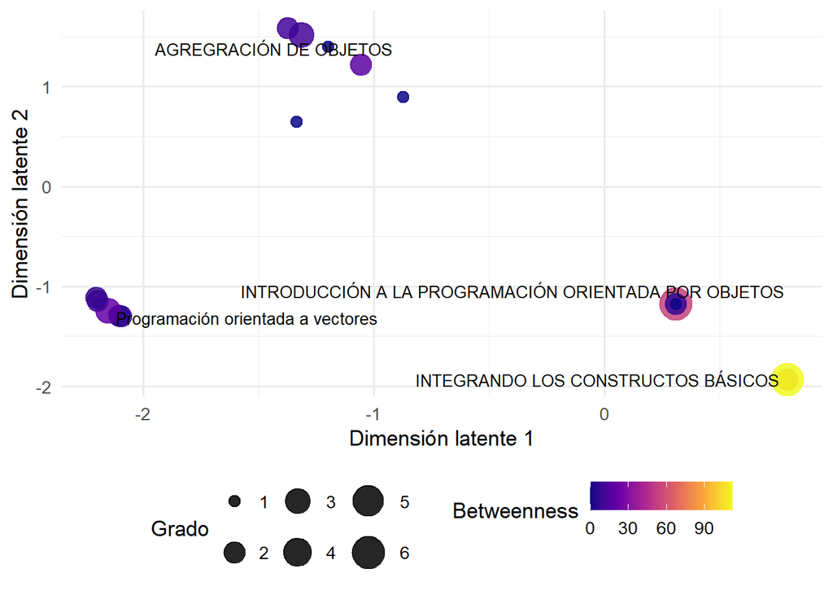

```r
ggplot(
  coord_c2,
  aes(
    V1,
    V2
  )
) +
  geom_point(
    aes(
      size = grado,
      color = bt
    ),
    alpha = .85
  ) +
  geom_text_repel(
    data = etiquetas,
    aes(label = concepto),
    size = 3.5,
    max.overlaps = Inf
  ) +
  scale_color_viridis_c(
    option = "C"
  ) +
  scale_size(range = c(3, 9)) +
  labs(
    x = "Dimensión latente 1",
    y = "Dimensión latente 2",
    color = "Betweenness",
    size = "Grado"
  ) +
  theme_minimal(base_size = 13) +
  theme(
    legend.position = "bottom"
  )
```

## 7.5 Comunidad 5 (21 conceptos)

```r
coord_c2 <- coord |>
  dplyr::filter(comunidad == 5)


etiquetas <- coord_c2 |>
  slice_max(grado, n = 3)
```

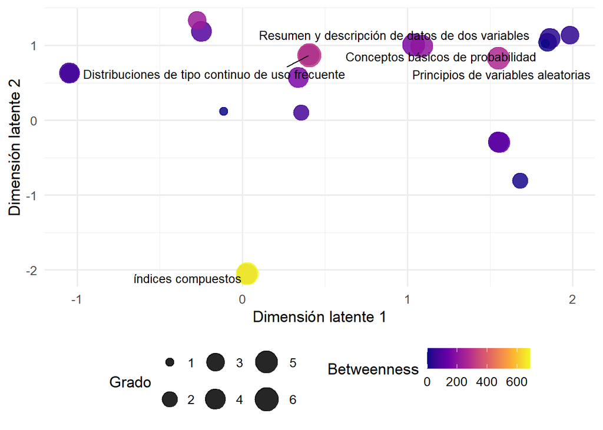

```r
ggplot(
  coord_c2,
  aes(
    V1,
    V2
  )
) +
  geom_point(
    aes(
      size = grado,
      color = bt
    ),
    alpha = .85
  ) +
  geom_text_repel(
    data = etiquetas,
    aes(label = concepto),
    size = 3.5,
    max.overlaps = Inf
  ) +
  scale_color_viridis_c(
    option = "C"
  ) +
  scale_size(range = c(3, 9)) +
  labs(
    x = "Dimensión latente 1",
    y = "Dimensión latente 2",
    color = "Betweenness",
    size = "Grado"
  ) +
  theme_minimal(base_size = 13) +
  theme(
    legend.position = "bottom"
  )
```

## 7.6 Comunidad 12 (18 conceptos)

```r
coord_c2 <- coord |>
  dplyr::filter(comunidad == 12)


etiquetas <- coord_c2 |>
  slice_max(grado, n = 4)
```

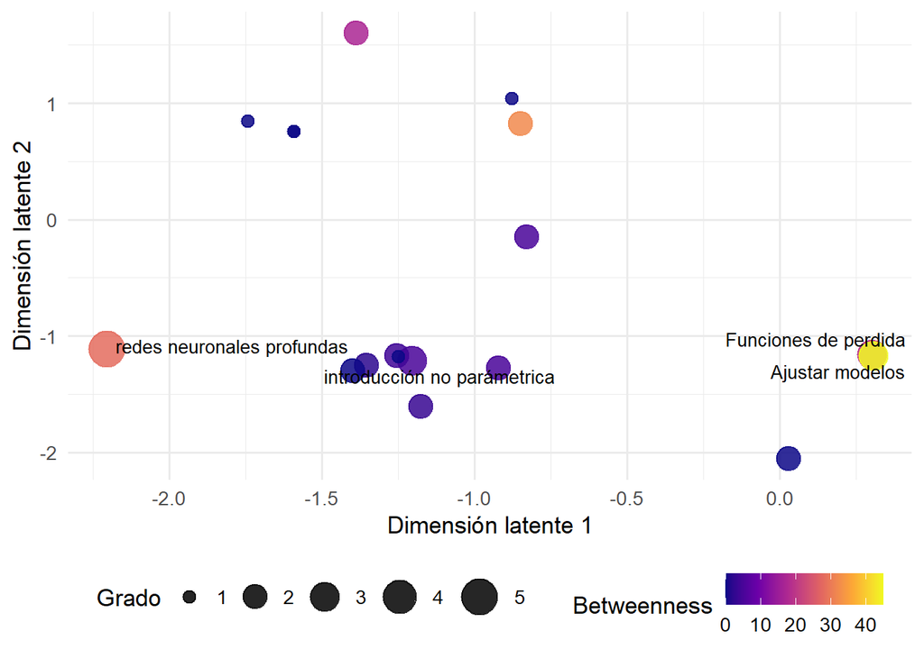

```r
ggplot(
  coord_c2,
  aes(
    V1,
    V2
  )
) +
  geom_point(
    aes(
      size = grado,
      color = bt
    ),
    alpha = .85
  ) +
  geom_text_repel(
    data = etiquetas,
    aes(label = concepto),
    size = 3.5,
    max.overlaps = Inf
  ) +
  scale_color_viridis_c(
    option = "C"
  ) +
  scale_size(range = c(3, 9)) +
  labs(
    x = "Dimensión latente 1",
    y = "Dimensión latente 2",
    color = "Betweenness",
    size = "Grado"
  ) +
  theme_minimal(base_size = 13) +
  theme(
    legend.position = "bottom"
  )
```

## 7.7 Comunidad 1 (17 conceptos)

```r
coord_c2 <- coord |>
  dplyr::filter(comunidad == 1)


etiquetas <- coord_c2 |>
  slice_max(grado, n = 3)
```

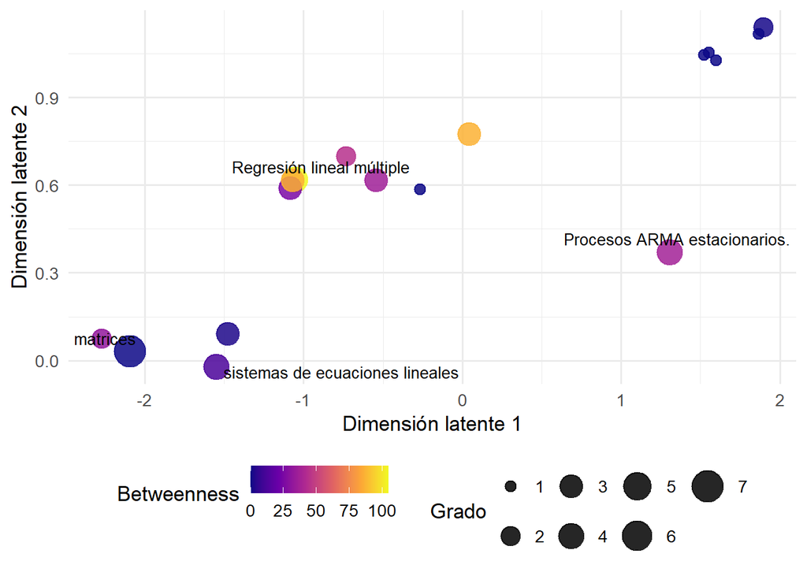

```r
ggplot(
  coord_c2,
  aes(
    V1,
    V2
  )
) +
  geom_point(
    aes(
      size = grado,
      color = bt
    ),
    alpha = .85
  ) +
  geom_text_repel(
    data = etiquetas,
    aes(label = concepto),
    size = 3.5,
    max.overlaps = Inf
  ) +
  scale_color_viridis_c(
    option = "C"
  ) +
  scale_size(range = c(3, 9)) +
  labs(
    x = "Dimensión latente 1",
    y = "Dimensión latente 2",
    color = "Betweenness",
    size = "Grado"
  ) +
  theme_minimal(base_size = 13) +
  theme(
    legend.position = "bottom"
  )
```

## 7.8 Tabla de parejas proximas

Las menores distancias obtenidas por el modelo corresponden en varios casos a conceptos pertenecientes a una misma línea temática (por ejemplo Convergencia–Distribuciones muestrales o Correspondencias simples y múltiples–Métodos de agrupamiento). Sin embargo, también aparecen pares sin relación disciplinar evidente. Esto ocurre porque algunos conceptos poseen muy pocas conexiones dentro de la red, de modo que el modelo de espacio latente no dispone de información suficiente para diferenciarlos y termina ubicándolos en posiciones prácticamente idénticas.

```r
D <- as.matrix(
  dist(coord[, c("V1","V2")])
)

tabla_distancias <-
  as.data.frame(as.table(D)) %>%
  rename(
    i = Var1,
    j = Var2,
    distancia = Freq
  ) %>%
  mutate(
    i = as.integer(as.character(i)),
    j = as.integer(as.character(j))
  ) %>%
  filter(i < j)

tabla_distancias$Concepto_A <-
  coord$ID_concepto[
    as.numeric(tabla_distancias$i)
  ]

tabla_distancias$Concepto_B <-
  coord$ID_concepto[
    as.numeric(tabla_distancias$j)
  ]

tabla_proximidad <-
  tabla_distancias %>%
  arrange(distancia) %>%
  slice(1:10) %>%
  select(
    Concepto_A,
    Concepto_B,
    distancia
  )

tabla_proximidad <-
  tabla_proximidad %>%
  mutate(
    Concepto_A = as.character(Concepto_A),
    Concepto_B = as.character(Concepto_B)
  ) %>%
  left_join(
    conceptos %>%
      select(
        ID_concepto,
        concepto
      ),
    by = c(
      "Concepto_A" = "ID_concepto"
    )
  ) %>%
  rename(
    Nombre_A = concepto
  ) %>%
  left_join(
    conceptos %>%
      select(
        ID_concepto,
        concepto
      ),
    by = c(
      "Concepto_B" = "ID_concepto"
    )
  ) %>%
  rename(
    Nombre_B = concepto
  ) %>%
  select(
    Nombre_A,
    Nombre_B,
    distancia
  )
```

```r
tabla_proximidad %>%
  kableExtra::kbl(
    caption = "Tabla 10 parejas proximas ",
    digits = 5
  ) %>%
  kableExtra::kable_minimal()
```

Table 7.1: Tabla 10 parejas proximas

| Nombre_A | Nombre_B | distancia |
| --- | --- | --- |
| Aspectos éticos de la práctica estadística | Aspectos filosóficos y administrativos de la normalización técnica | 0 |
| FUNCIONES 5.1. | CARDINALES 6.1. | 0 |
| INTRODUCCIÓN A LA PROGRAMACIÓN DE COMPUTADORES | redes neuronales superficiales | 0 |
| Aprendizaje supervisado | Aprendizaje no supervisado | 0 |
| introduccion espacial | Metabolismo | 0 |
| introduccion espacial | El valor de la información estadística en la sociedad y estados modernos | 0 |
| Correspondencias simples y múltiples | Métodos de agrupamiento | 0 |
| Convergencia | Distribuciones muéstrales | 0 |
| CONSTRUCTOS BÁSICOS II y III (CONDICIONALES) DE PROGRAMACIÓN | Análisis exploratorio de datos | 0 |
| Distribuciones muéstrales | Pruebas de hipótesis | 0 |

# 8 Algoritmo de inferencia de prerrequisitos curriculares

La red de cursos se construyó a partir de la red de relaciones entre conceptos y de la asignación de cada concepto a una asignatura. El procedimiento implementado consta de las siguientes etapas:

1. **Asignación del curso de origen y destino**

Cada relación entre conceptos ($c_{i},c_{j}$) se enriqueció identificando la asignatura a la que pertenece cada concepto. Para ello se realizaron dos uniones (*left join*) con la tabla de asociación curso–concepto. Como resultado, cada relación quedó representada como

$$(Curso_{i},Concepto_{i},Curso_{j}, Concepto_{j})$$

2. **Eliminación de relaciones internas**

Se descartaron las relaciones en las que ambos conceptos pertenecían al mismo curso ($i=j$)

3. **Conteo de relaciones entre cursos**

Posteriormente se contabilizó el número de relaciones conceptuales existentes entre cada par ordenado de cursos.

Si existen $r_{ij}$ relaciones cuyos conceptos parten del curso $i$ hacia el curso $j$, entonces

$$r_{ij}=|\{(c_a,c_b):c_a \in i, c_b \in j\}|$$

4. **Normalización por el tamaño del curso destino**

Como las asignaturas contienen diferentes cantidades de conceptos, utilizar únicamente el número de relaciones favorecería a los cursos más grandes. Para evitar este sesgo, se calculó el número de conceptos de cada curso destino, $n_j=$número de conceptos del curso j, y se definió el peso de la arista como

$$w_{ij}=\frac{r_{ij}}{n_{j}}$$

De esta manera, el peso representa la proporción de conceptos del curso destino que dependen de conocimientos provenientes del curso origen.

Para la visualización de la red completa se uso la componente curricular para dar el color, sin embargo se uso el algoritmo de Louvain para generar comunidades **de los cursos** así como antes se analizaron las más grandes.

```r
conceptos_relaciones <- relaciones %>%
  left_join(
    curso_concepto %>%
      select(ID_curso, ID_concepto),
    by = c("ID_concepto_origen" = "ID_concepto")
  ) %>%
  rename(Curso_origen = ID_curso)
conceptos_relaciones <- conceptos_relaciones %>%
  left_join(
    curso_concepto %>%
      select(ID_curso, ID_concepto),
    by = c("ID_concepto_destino" = "ID_concepto")
  ) %>%
  rename(Curso_destino = ID_curso)
```

```r
conceptos_relaciones <- conceptos_relaciones %>%
  filter(Curso_origen != Curso_destino)

red_cursos <- conceptos_relaciones %>%
  count(
    Curso_origen,
    Curso_destino,
    name = "peso"
  ) %>%
  arrange(desc(peso))

red_cursos <- red_cursos %>%
  left_join(
    cursos %>%
      select(ID_curso, curso),
    by = c("Curso_origen" = "ID_curso")
  ) %>%
  rename(Nombre_origen = curso) %>%
  left_join(
    cursos %>%
      select(ID_curso, curso),
    by = c("Curso_destino" = "ID_curso")
  ) %>%
  rename(Nombre_destino = curso)


n_conceptos <- curso_concepto %>%
  distinct(ID_curso, ID_concepto) %>%
  count(
    ID_curso,
    name = "n_conceptos"
  )

red_cursos <- conceptos_relaciones %>%
  count(
    Curso_origen,
    Curso_destino,
    name = "n_relaciones"
  )

red_cursos <- red_cursos %>%
  left_join(
    n_conceptos,
    by = c(
      "Curso_destino" = "ID_curso"
    )
  ) %>%
  mutate(
    peso = n_relaciones / n_conceptos
  )

g_cursos <- graph_from_data_frame(
  red_cursos,
  directed = TRUE,
  vertices = cursos
)

com_cursos <- cluster_louvain(
    as_undirected(g_cursos)
)

V(g_cursos)$size <- scales::rescale(
  degree(g_cursos, mode = "out"),
  to = c(8,20)
)

niveles <- unique(cursos$componente)

cols <- setNames(
  RColorBrewer::brewer.pal(length(niveles),"Set3"),
  niveles
)

V(g_cursos)$color <-
  cols[V(g_cursos)$componente]

E(g_cursos)$width <- scales::rescale(
  E(g_cursos)$peso,
  to = c(1,8)
)

g_cursos2 <- delete_edges(
  g_cursos,
  E(g_cursos)[peso < quantile(E(g_cursos)$peso,.75)]
)
layoutgcursos <- layout_in_circle(g_cursos)


g1 <- induced_subgraph(
    g_cursos,
    membership(com_cursos) == 1
)

g2 <- induced_subgraph(
    g_cursos,
    membership(com_cursos) == 5
)

g3 <- induced_subgraph(
    g_cursos,
    membership(com_cursos) == 9
)

g4 <- induced_subgraph(
    g_cursos,
    membership(com_cursos) == 2
)

g5 <- induced_subgraph(
    g_cursos,
    membership(com_cursos) == 4
)

g6 <- induced_subgraph(
    g_cursos,
    membership(com_cursos) == 3
)

g23 <- induced_subgraph(
    g_cursos,
    membership(com_cursos) %in% c(5,9)
)

g24 <- induced_subgraph(
    g_cursos,
    membership(com_cursos) %in% c(5,2)
)

g34 <- induced_subgraph(
    g_cursos,
    membership(com_cursos) %in% c(9,2)
)
```

### 8.0.1 Red total

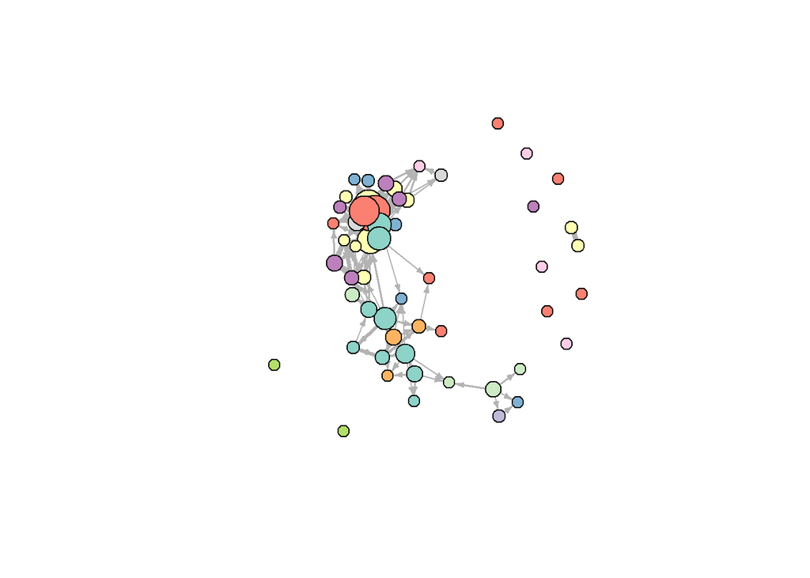

```r
set.seed(1302)

plot(
  g_cursos,
  edge.arrow.size = .35,
  edge.color = "grey70",
  vertex.label=""
)
```

### 8.0.2 Componente 1 (Fundamentación matemática)

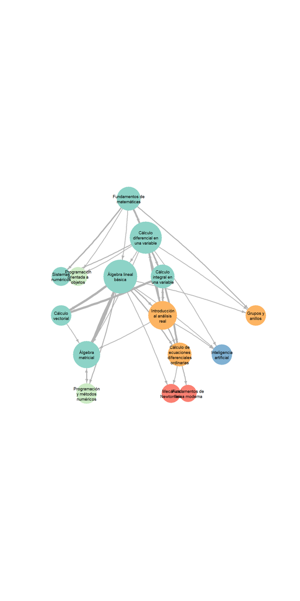

```r
layoutgcursos <- layout_with_sugiyama(g1)$layout
V(g1)$size <- scales::rescale(
  degree(g1, mode = "all"),
  to = c(18, 35)
)
V(g1)$label <- V(g1)$curso

V(g1)$label <-
  str_wrap(
    V(g1)$curso,
    width = 14
  )
plot(
  g1,
  layout=layoutgcursos,
  edge.color = "grey70",
  vertex.frame.color = NA,
  edge.arrow.size = .45,
edge.width = scales::rescale(E(g1)$peso, c(1.5,6)),
edge.color = "grey55",
edge.curved = .05,
vertex.label.cex = .6,
vertex.label.family = "sans",
vertex.label.color = "black"
)
```

Aunque el grafo obtenido es bastante similar al pensum vigente, se observa una diferencia relevante en el componente de análisis:

- En el plan de estudios actual, Introducción al análisis real y Cálculo de ecuaciones diferenciales ordinarias pertenecen al mismo componente y cualquiera de las dos asignaturas permite cumplir el requisito de créditos correspondiente. Sin embargo, el modelo ubica a Introducción al análisis real como un nodo más central, conectado con un mayor número de asignaturas posteriores. Esto sugiere que, para estudiantes que únicamente necesiten cursar una asignatura del componente, Introducción al análisis real podría aportar una base conceptual más amplia y facilitar el acceso a conocimientos utilizados en cursos posteriores.
- Una diferencia respecto al pensum actual es que el algoritmo propone que Programación y métodos numéricos dependa tanto de Álgebra lineal básica como de Álgebra matricial, mientras que en el currículo vigente únicamente se exige Álgebra lineal básica. Esto puede interpretarse como una evidencia de que los contenidos de álgebra matricial constituyen un soporte conceptual importante para comprender algunos de los métodos desarrollados en la asignatura, aunque dicha relación no se encuentre formalizada como prerrequisito.
- Otra diferencia importante se observa en las asignaturas Mecánica newtoniana y Fundamentos de física moderna. En el pensum vigente estas materias no tienen prerrequisitos formales; sin embargo, el modelo propone como prerrequisito Cálculo de ecuaciones diferenciales ordinarias. Esta relación resulta consistente con los contenidos de ambas asignaturas, ya que numerosos modelos físicos se describen mediante ecuaciones diferenciales, tanto en la formulación de la mecánica clásica como en diversos problemas de la física moderna. En consecuencia, el algoritmo identifica una dependencia conceptual que podría facilitar la comprensión de estos cursos, aunque actualmente no se encuentre establecida en la estructura curricular.

### 8.0.3 Componente 2 (Fundamentación estadística)

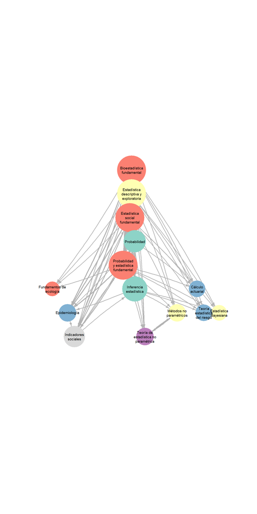

```r
layoutgcursos <- layout_with_sugiyama(g2)$layout
V(g2)$size <- scales::rescale(
  degree(g2, mode = "all"),
  to = c(18, 35)
)
V(g2)$label <- V(g2)$curso
library(stringr)

V(g2)$label <-
  str_wrap(
    V(g2)$curso,
    width = 14
  )
plot(
  g2,
  layout=layoutgcursos,
  edge.color = "grey70",
  vertex.frame.color = NA,
  edge.arrow.size = .45,
edge.width = scales::rescale(E(g2)$peso, c(1.5,6)),
edge.color = "grey55",
edge.curved = .05,
vertex.label.cex = .6,
vertex.label.family = "sans",
vertex.label.color = "black"
)
```

El algoritmo sugiere que la asignatura Indicadores sociales debería cursarse después de una materia que proporcione los fundamentos de la inferencia estadística. Aunque el plan de estudios vigente permite cursarla sin este antecedente, la construcción e interpretación de indicadores sociales requiere comprender conceptos como estimación, error de muestreo, intervalos de confianza e inferencia sobre poblaciones. En este sentido, una asignatura como Probabilidad y Estadística Fundamental, en la que se introducen estos conceptos, podría constituir un prerrequisito conceptual suficiente. Si bien un curso de Inferencia Estadística proporcionaría una formación más profunda, no resulta estrictamente necesario para alcanzar los objetivos de la asignatura.

### 8.0.4 Componente 3 (Muestreo)

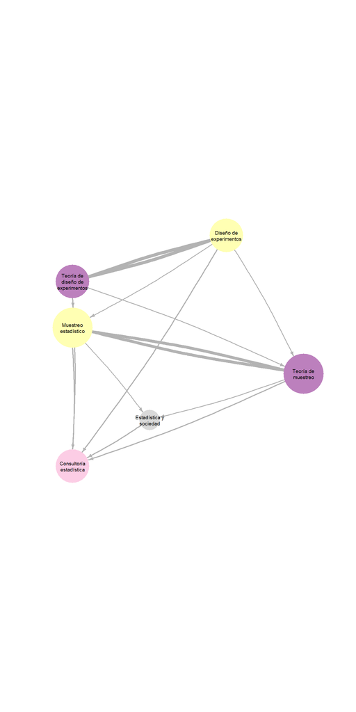

```r
layoutgcursos <- layout_with_sugiyama(g3)$layout
V(g3)$size <- scales::rescale(
  degree(g3, mode = "all"),
  to = c(18, 35)
)
V(g3)$label <- V(g3)$curso
library(stringr)

V(g3)$label <-
  str_wrap(
    V(g3)$curso,
    width = 14
  )
plot(
  g3,
  layout=layoutgcursos,
  edge.color = "grey70",
  vertex.frame.color = NA,
  edge.arrow.size = .45,
edge.width = scales::rescale(E(g3)$peso, c(1.5,6)),
edge.color = "grey55",
edge.curved = .05,
vertex.label.cex = .6,
vertex.label.family = "sans",
vertex.label.color = "black"
)
```

Una diferencia llamativa corresponde a la relación entre Diseño de experimentos y Muestreo estadístico. Mientras que el algoritmo ubica a Diseño de experimentos como antecedente de Muestreo estadístico, esta organización difiere de la secuencia que intuitivamente podría esperarse. Este resultado puede deberse a la estructura de las relaciones conceptuales registradas en la base de conocimiento, por lo que constituye un caso que amerita una revisión detallada de las dependencias definidas entre conceptos y de su asignación a las diferentes asignaturas.

### 8.0.5 Componente 4 (Regresión)

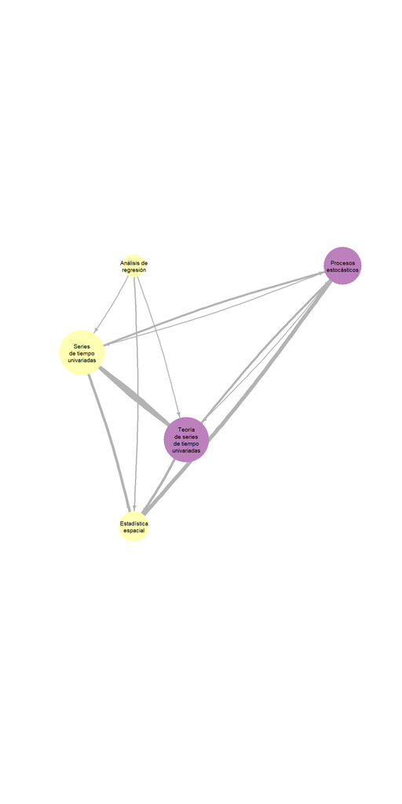

```r
layoutgcursos <- layout_with_sugiyama(g4)$layout
V(g4)$size <- scales::rescale(
  degree(g4, mode = "all"),
  to = c(18, 35)
)
V(g4)$label <- V(g4)$curso
library(stringr)

V(g4)$label <-
  str_wrap(
    V(g4)$curso,
    width = 14
  )
plot(
  g4,
  layout=layoutgcursos,
  edge.color = "grey70",
  vertex.frame.color = NA,
  edge.arrow.size = .45,
edge.width = scales::rescale(E(g4)$peso, c(1.5,6)),
edge.color = "grey55",
edge.curved = .05,
vertex.label.cex = .6,
vertex.label.family = "sans",
vertex.label.color = "black"
)
```

En la asignatura Estadística espacial, el plan de estudios vigente establece como único prerrequisito Análisis de regresión. No obstante, el algoritmo identifica que los cursos de Procesos estocásticos y Series de tiempo univariadas también constituyen antecedentes conceptuales relevantes. Esta relación es consistente con los fundamentos de la estadística espacial, en los que el análisis de la dependencia espacial puede abordarse desde la teoría de procesos estocásticos y comparte herramientas metodológicas con el análisis de series de tiempo, particularmente en el estudio de estructuras de dependencia y correlación. En consecuencia, el algoritmo sugiere que cursar estas asignaturas previamente podría proporcionar una base teórica más sólida para el desarrollo de los contenidos de estadística espacial.

### 8.0.6 Componente 5 (Programación)

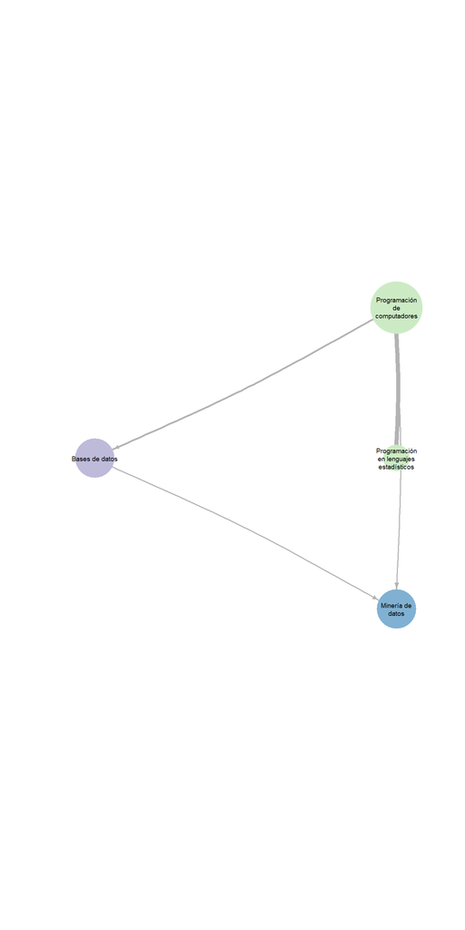

```r
layoutgcursos <- layout_with_sugiyama(g5)$layout
V(g5)$size <- scales::rescale(
  degree(g5, mode = "all"),
  to = c(18, 35)
)
V(g5)$label <- V(g5)$curso
library(stringr)

V(g5)$label <-
  str_wrap(
    V(g5)$curso,
    width = 14
  )
plot(
  g5,
  layout=layoutgcursos,
  edge.color = "grey70",
  vertex.frame.color = NA,
  edge.arrow.size = .45,
edge.width = scales::rescale(E(g5)$peso, c(1.5,6)),
edge.color = "grey55",
edge.curved = .05,
vertex.label.cex = .6,
vertex.label.family = "sans",
vertex.label.color = "black"
)
```

El algoritmo identifica que Minería de datos debería cursarse después de Programación en lenguajes estadísticos y Bases de datos. En el plan de estudios vigente, esta asignatura no posee prerrequisitos formales; sin embargo, la dependencia propuesta resulta consistente con sus contenidos. El análisis de grandes volúmenes de datos requiere competencias en programación para la implementación de algoritmos y el manejo de librerías especializadas, así como conocimientos en bases de datos para la extracción, consulta y preparación de la información. En este sentido, el algoritmo sugiere que estos cursos proporcionan herramientas fundamentales para el desarrollo de la asignatura.

### 8.0.7 Componentes 2 y 4

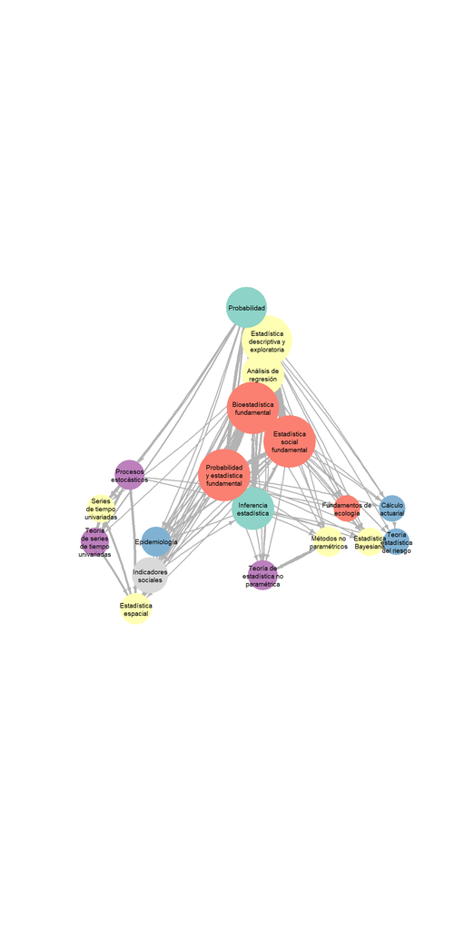

```r
layoutgcursos <- layout_with_sugiyama(g24)$layout
V(g24)$size <- scales::rescale(
  degree(g24, mode = "all"),
  to = c(18, 35)
)
V(g24)$label <- V(g24)$curso
library(stringr)

V(g24)$label <-
  str_wrap(
    V(g24)$curso,
    width = 14
  )
plot(
  g24,
  layout=layoutgcursos,
  edge.color = "grey70",
  vertex.frame.color = NA,
  edge.arrow.size = .45,
edge.width = scales::rescale(E(g24)$peso, c(1.5,6)),
edge.color = "grey55",
edge.curved = .05,
vertex.label.cex = .6,
vertex.label.family = "sans",
vertex.label.color = "black"
)
```

En este componente también se observa que el algoritmo ubica Métodos no paramétricos después de Análisis de regresión, mientras que en el plan de estudios vigente esta asignatura tiene como prerrequisito Inferencia estadística. Esta diferencia resulta razonable, ya que dentro de los contenidos de Métodos no paramétricos se incluyen técnicas de regresión no paramétrica, lo que justifica la dependencia identificada por el algoritmo.

Por otra parte, el algoritmo sitúa Análisis de regresión después de Estadística descriptiva y exploratoria. Sin embargo, este resultado debe interpretarse con cautela, pues la descripción oficial de esta asignatura incluye contenidos que abarcan no solo estadística descriptiva, sino también probabilidad, inferencia estadística e incluso regresión lineal. Como consecuencia, el algoritmo la identifica como una asignatura con una base conceptual mucho más amplia de la que su nombre sugiere y la ubica próxima a asignaturas de servicio como Bioestadística fundamental y Estadística social fundamental, cuyos contenidos, según la información oficial del plan de estudios, son muy similares. En este caso, la posición obtenida responde a la estructura de los contenidos registrados y no necesariamente a una recomendación sobre el orden óptimo de cursar las asignaturas.

# 9 Conclusiones

- El algoritmo basado en **Modelos de Bloques Estocásticos** (SBM) permitió identificar que el conjunto de asignaturas del programa de Estadística de la Universidad Nacional presenta una estructura altamente integrada, evidenciando que los conceptos se organizan en comunidades temáticas con relaciones coherentes entre sí.
- La calidad de los resultados obtenidos depende directamente de la definición de los conceptos y de las relaciones establecidas entre ellos. En particular, asignaturas cuyas descripciones incluyen contenidos introductorios de varias áreas pueden generar dependencias que no reflejan necesariamente la secuencia curricular deseada. Un ejemplo de ello es la ubicación de Análisis de regresión después de Estadística descriptiva y exploratoria, resultado que se explica porque esta última, según la descripción oficial del curso, incluye conceptos básicos de probabilidad, inferencia y regresión lineal. En trabajos futuros sería conveniente definir con mayor precisión el alcance de cada concepto y el nivel de profundidad con el que se aborda en cada asignatura.
- En términos generales, el algoritmo reproduce de manera satisfactoria la estructura del pensum vigente, lo que constituye una evidencia de la consistencia del diseño curricular actual. No obstante, también identifica dependencias conceptuales que no se encuentran formalizadas como prerrequisitos, como ocurre en asignaturas como Minería de datos, Estadística espacial, Programación y métodos numéricos o algunas asignaturas del área de física. Estos resultados pueden servir como insumo para futuras revisiones curriculares o como recomendaciones para que los estudiantes planifiquen de manera más adecuada la secuencia de cursos que desean tomar.
- La metodología propuesta demuestra que es posible utilizar técnicas de análisis de redes para estudiar la estructura conceptual de un plan de estudios y apoyar la identificación de prerrequisitos entre asignaturas. En este sentido, el algoritmo no busca reemplazar el criterio académico empleado en el diseño curricular, sino proporcionar una herramienta objetiva que complemente dicho proceso mediante el análisis de las dependencias conceptuales existentes entre los cursos.

# Referencias

Universidad Nacional de Colombia. s.f.a. *Buscador de Cursos*. https://sia.unal.edu.co/Catalogo/facespublico/public/servicioPublico.jsf.

Universidad Nacional de Colombia. s.f.b. *Consulta de Contenidos de Asignaturas*. https://siabog.unal.edu.co/academia/apoyo-administrativo/ConsultaContenidos.do.

Universidad Nacional de Colombia. s.f.c. *Proyecto Educativo Del Programa (PEP): Estadística*. https://diracad.bogota.unal.edu.co/recursos/pdf/unal-aspirante/PEP/PEP-estadistica.pdf.